# Bellabeat Case Study

Swathy Ajaya Kumar

2022-09-30

*This Case Study is the Capstone Project for the Google Data Analytics Course. The ideas and recommendations presented here in no way represent the ideas and belief of Google or Bellabeat. This project is completed for learning purposes only and may be inaccurate. The views expressed here are my own.*

*Assumption:* *I am a junior data analyst working on the marketing analyst team at Bellabeat, a high-tech manufacturer of health-focused products for women. I have been asked to focus on one of Bellabeat’s products and analyze smart device data to gain insight into how consumers are using their smart devices. The insights will help guide marketing strategy for the company. The result of this analysis is assumed to be presented to the Bellabeat executive team along with high-level recommendations for Bellabeat’s marketing strategy.*

### About Bellabeat

Founded in 2013 by Urška Sršen and Sando Mur, Bellabeat is high-tech company that manufactures beautifully designed health-focused smart products for women. Bellabeat products empower women with knowledge about their own health and habits by collecting data on activity, sleep, stress,and reproductive health.

### Our Products

Our wearables and accompanying products monitor biometric and lifestyle data to help women better understand how their bodies work and make healthier choices.

1. **Bellabeat app:** Provides users with health data related to their activity, sleep, stress, menstrual cycle, and mindfulness habits. This app connects to our line of smart wellness products mentioned below.
2. **Leaf:** Wellness trackers that can be worn as a bracelet, necklace, or clip.
3. **Time:** Wellness SmartWatch is timepiece with smart technology to track user activity, sleep, and stress.
4. **Spring:** Smart Water Bottle that tracks daily water intake using smart technology to ensure that our users are appropriately hydrated throughout the day.
5. **Bellabeat membership:** We offer subscription-based membership program for users which gives users 24/7 access to fully personalized guidance on nutrition, activity, sleep, health and beauty, and mindfulness based on their lifestyle and goals.

### SWOT Analysis - Analysing Strengths, Weaknesses, Opportunities and Threats

#### Strengths

1. **Product Line-up:** Bellabeat’s versatile product line-up includes wearable jewellery trackers, smart water bottle and smartwatch which can all be linked to the an app which can actively track activity,sleep, stress, menstrual cycle, and mindfulness habits.
2. **Beautiful Designs** Our products are beautifully and elegantly designed by women, for women.
3. **Affordable Price Point** Our products are affordably priced compared to competitor products. Smart watches are priced at $149.00 USD + tax, and come with free 3 months subscription to personalized wellness coaching.

#### Opportunities

1. **Introduce wireless charging** We could modify our products to be compatible with wireless charging. We could sell wireless charging pods which are compatible with all our products.
2. **Customization** Our products are all elegantly designed. We could add more funky, sporty and trendy looks to accomodate the taste of more women. Not all women prefer minimalistic designs.

#### Weaknesses

1. **Replaceable batteries** Bellabeat products currently use long-lasting, replaceable batteries. They last about 3-6 months. Disposable batteries contribute to e-waste.
2. **Limited options for customization** There aren’t many options to choose from while selecting the style of products, especially the Leaf line-up. This might turn women away from buying our products

#### Threats

1. **Data Safety** On the wake of Roe v Wade being overturned, many women are worried if their reproductive data would be shared with the authorities. Therefore, many women are hesitant to track period data. Period data is essential for our personalized wellness program. We have enabled Private Key Encryption (AES-256) security feature for our mobile app to protect women’s reproductive information. Bellabeat must find ways to protect women’s rights in changing political landscape.
2. **Competitor Threat** Bellabeat face strict competition from Fitbit, Samsung and Apple Watch. These products have economies of scale and have considerable market share. We must consistently push our Unique Selling Point (wellness products for women) to capture more of ther market share.

## Exploring Growth Opportunities

## Business Task

Urška Sršen, cofounder and Chief Creative Officer of Bellabeat is the *primary stakeholder* of this case study. Through this study, we will analyze smart device fitness data which will help unlock new growth opportunities for Bellabeat.

## Preparing Data

### Install Packages

We are using R to analyse this dataset. The following summarizes the packages that are installed to help us analyze user data.

```r
install.packages("tidyverse")
install.packages("dplyr")
install.packages("skimr")
install.packages("here")
install.packages("janitor")
install.packages("tidyr")
```

```r
install.packages("ggplot2")
install.packages("lubridate")
library("tidyverse")
library("dplyr")
library("skimr")
library("tidyr")
library("ggplot2")
library("lubridate")
library("here")
library("janitor")
```

## Uploading Datasets

```r
dailyActivity <- read_csv("dailyActivity_merged.csv")
dailysleep <- read_csv("sleepDay_merged.csv")
dailyweight <- read_csv("weightLogInfo_merged.csv")
```

#### Cleaning up data

##### Removing empty rows and columns

```r
 remove_empty(dailyActivity, which = c("rows", "cols"))
```

```
## # A tibble: 940 × 15
##            Id Activity…¹ Total…² Total…³ Track…⁴ Logge…⁵ VeryA…⁶ Moder…⁷ Light…⁸
##         <dbl> <chr>        <dbl>   <dbl>   <dbl>   <dbl>   <dbl>   <dbl>   <dbl>
##  1 1503960366 4/12/2016    13162    8.5     8.5        0    1.88   0.550    6.06
##  2 1503960366 4/13/2016    10735    6.97    6.97       0    1.57   0.690    4.71
##  3 1503960366 4/14/2016    10460    6.74    6.74       0    2.44   0.400    3.91
##  4 1503960366 4/15/2016     9762    6.28    6.28       0    2.14   1.26     2.83
##  5 1503960366 4/16/2016    12669    8.16    8.16       0    2.71   0.410    5.04
##  6 1503960366 4/17/2016     9705    6.48    6.48       0    3.19   0.780    2.51
##  7 1503960366 4/18/2016    13019    8.59    8.59       0    3.25   0.640    4.71
##  8 1503960366 4/19/2016    15506    9.88    9.88       0    3.53   1.32     5.03
##  9 1503960366 4/20/2016    10544    6.68    6.68       0    1.96   0.480    4.24
## 10 1503960366 4/21/2016     9819    6.34    6.34       0    1.34   0.350    4.65
## # … with 930 more rows, 6 more variables: SedentaryActiveDistance <dbl>,
## #   VeryActiveMinutes <dbl>, FairlyActiveMinutes <dbl>,
## #   LightlyActiveMinutes <dbl>, SedentaryMinutes <dbl>, Calories <dbl>, and
## #   abbreviated variable names ¹ActivityDate, ²TotalSteps, ³TotalDistance,
## #   ⁴TrackerDistance, ⁵LoggedActivitiesDistance, ⁶VeryActiveDistance,
## #   ⁷ModeratelyActiveDistance, ⁸LightActiveDistance
```

```r
 remove_empty(dailysleep, which = c("rows", "cols"))
```

```
## # A tibble: 413 × 5
##            Id SleepDay              TotalSleepRecords TotalMinutesAsleep Total…¹
##         <dbl> <chr>                             <dbl>              <dbl>   <dbl>
##  1 1503960366 4/12/2016 12:00:00 AM                 1                327     346
##  2 1503960366 4/13/2016 12:00:00 AM                 2                384     407
##  3 1503960366 4/15/2016 12:00:00 AM                 1                412     442
##  4 1503960366 4/16/2016 12:00:00 AM                 2                340     367
##  5 1503960366 4/17/2016 12:00:00 AM                 1                700     712
##  6 1503960366 4/19/2016 12:00:00 AM                 1                304     320
##  7 1503960366 4/20/2016 12:00:00 AM                 1                360     377
##  8 1503960366 4/21/2016 12:00:00 AM                 1                325     364
##  9 1503960366 4/23/2016 12:00:00 AM                 1                361     384
## 10 1503960366 4/24/2016 12:00:00 AM                 1                430     449
## # … with 403 more rows, and abbreviated variable name ¹TotalTimeInBed
```

```r
 remove_empty(dailyweight, which = c("rows", "cols"))
```

```
## # A tibble: 67 × 8
##            Id Date                  WeightKg Weigh…¹   Fat   BMI IsMan…²   LogId
##         <dbl> <chr>                    <dbl>   <dbl> <dbl> <dbl> <lgl>     <dbl>
##  1 1503960366 5/2/2016 11:59:59 PM      52.6    116.    22  22.6 TRUE    1.46e12
##  2 1503960366 5/3/2016 11:59:59 PM      52.6    116.    NA  22.6 TRUE    1.46e12
##  3 1927972279 4/13/2016 1:08:52 AM     134.     294.    NA  47.5 FALSE   1.46e12
##  4 2873212765 4/21/2016 11:59:59 PM     56.7    125.    NA  21.5 TRUE    1.46e12
##  5 2873212765 5/12/2016 11:59:59 PM     57.3    126.    NA  21.7 TRUE    1.46e12
##  6 4319703577 4/17/2016 11:59:59 PM     72.4    160.    25  27.5 TRUE    1.46e12
##  7 4319703577 5/4/2016 11:59:59 PM      72.3    159.    NA  27.4 TRUE    1.46e12
##  8 4558609924 4/18/2016 11:59:59 PM     69.7    154.    NA  27.2 TRUE    1.46e12
##  9 4558609924 4/25/2016 11:59:59 PM     70.3    155.    NA  27.5 TRUE    1.46e12
## 10 4558609924 5/1/2016 11:59:59 PM      69.9    154.    NA  27.3 TRUE    1.46e12
## # … with 57 more rows, and abbreviated variable names ¹WeightPounds,
## #   ²IsManualReport
```

##### Check number of users

```r
n_distinct(dailyActivity$Id)
```

```
## [1] 33
```

```r
n_distinct(dailysleep$Id)
```

```
## [1] 24
```

```r
n_distinct(dailyweight$Id)
```

```
## [1] 8
```

There are 33, 24 and 8 distinct user IDs reported for daily activity, sleep and weight log respectively.

##### Check for duplicates

```r
sum(duplicated(dailyActivity))
```

```
## [1] 0
```

```r
sum(duplicated(dailysleep))
```

```
## [1] 3
```

```r
sum(duplicated(dailyweight))
```

```
## [1] 0
```

The Sleep log has 3 duplicate values. We would have to remove them.

```r
dailysleep <- dailysleep %>%
  distinct() %>%
  drop_na()
```

```r
sum(duplicated(dailysleep))
```

```
## [1] 0
```

##### Standard column names

Using the clean names function to standardize column names.

```r
dailyActivity <- clean_names(dailyActivity)
dailysleep <- clean_names(dailysleep)
dailyweight <- clean_names(dailyweight)

head(dailyActivity)
```

```
## # A tibble: 6 × 15
##       id activ…¹ total…² total…³ track…⁴ logge…⁵ very_…⁶ moder…⁷ light…⁸ seden…⁹
##    <dbl> <chr>     <dbl>   <dbl>   <dbl>   <dbl>   <dbl>   <dbl>   <dbl>   <dbl>
## 1 1.50e9 4/12/2…   13162    8.5     8.5        0    1.88   0.550    6.06       0
## 2 1.50e9 4/13/2…   10735    6.97    6.97       0    1.57   0.690    4.71       0
## 3 1.50e9 4/14/2…   10460    6.74    6.74       0    2.44   0.400    3.91       0
## 4 1.50e9 4/15/2…    9762    6.28    6.28       0    2.14   1.26     2.83       0
## 5 1.50e9 4/16/2…   12669    8.16    8.16       0    2.71   0.410    5.04       0
## 6 1.50e9 4/17/2…    9705    6.48    6.48       0    3.19   0.780    2.51       0
## # … with 5 more variables: very_active_minutes <dbl>,
## #   fairly_active_minutes <dbl>, lightly_active_minutes <dbl>,
## #   sedentary_minutes <dbl>, calories <dbl>, and abbreviated variable names
## #   ¹activity_date, ²total_steps, ³total_distance, ⁴tracker_distance,
## #   ⁵logged_activities_distance, ⁶very_active_distance,
## #   ⁷moderately_active_distance, ⁸light_active_distance,
## #   ⁹sedentary_active_distance
```

```r
head(dailysleep)
```

```
## # A tibble: 6 × 5
##           id sleep_day             total_sleep_records total_minutes_a…¹ total…²
##        <dbl> <chr>                               <dbl>             <dbl>   <dbl>
## 1 1503960366 4/12/2016 12:00:00 AM                   1               327     346
## 2 1503960366 4/13/2016 12:00:00 AM                   2               384     407
## 3 1503960366 4/15/2016 12:00:00 AM                   1               412     442
## 4 1503960366 4/16/2016 12:00:00 AM                   2               340     367
## 5 1503960366 4/17/2016 12:00:00 AM                   1               700     712
## 6 1503960366 4/19/2016 12:00:00 AM                   1               304     320
## # … with abbreviated variable names ¹total_minutes_asleep, ²total_time_in_bed
```

```r
head(dailyweight)
```

```
## # A tibble: 6 × 8
##           id date                  weight_kg weigh…¹   fat   bmi is_ma…²  log_id
##        <dbl> <chr>                     <dbl>   <dbl> <dbl> <dbl> <lgl>     <dbl>
## 1 1503960366 5/2/2016 11:59:59 PM       52.6    116.    22  22.6 TRUE    1.46e12
## 2 1503960366 5/3/2016 11:59:59 PM       52.6    116.    NA  22.6 TRUE    1.46e12
## 3 1927972279 4/13/2016 1:08:52 AM      134.     294.    NA  47.5 FALSE   1.46e12
## 4 2873212765 4/21/2016 11:59:59 PM      56.7    125.    NA  21.5 TRUE    1.46e12
## 5 2873212765 5/12/2016 11:59:59 PM      57.3    126.    NA  21.7 TRUE    1.46e12
## 6 4319703577 4/17/2016 11:59:59 PM      72.4    160.    25  27.5 TRUE    1.46e12
## # … with abbreviated variable names ¹weight_pounds, ²is_manual_report
```

##### Check the structure of each table

```r
str(dailyActivity)
```

```
## spc_tbl_ [940 × 15] (S3: spec_tbl_df/tbl_df/tbl/data.frame)
##  $ id                        : num [1:940] 1.5e+09 1.5e+09 1.5e+09 1.5e+09 1.5e+09 ...
##  $ activity_date             : chr [1:940] "4/12/2016" "4/13/2016" "4/14/2016" "4/15/2016" ...
##  $ total_steps               : num [1:940] 13162 10735 10460 9762 12669 ...
##  $ total_distance            : num [1:940] 8.5 6.97 6.74 6.28 8.16 ...
##  $ tracker_distance          : num [1:940] 8.5 6.97 6.74 6.28 8.16 ...
##  $ logged_activities_distance: num [1:940] 0 0 0 0 0 0 0 0 0 0 ...
##  $ very_active_distance      : num [1:940] 1.88 1.57 2.44 2.14 2.71 ...
##  $ moderately_active_distance: num [1:940] 0.55 0.69 0.4 1.26 0.41 ...
##  $ light_active_distance     : num [1:940] 6.06 4.71 3.91 2.83 5.04 ...
##  $ sedentary_active_distance : num [1:940] 0 0 0 0 0 0 0 0 0 0 ...
##  $ very_active_minutes       : num [1:940] 25 21 30 29 36 38 42 50 28 19 ...
##  $ fairly_active_minutes     : num [1:940] 13 19 11 34 10 20 16 31 12 8 ...
##  $ lightly_active_minutes    : num [1:940] 328 217 181 209 221 164 233 264 205 211 ...
##  $ sedentary_minutes         : num [1:940] 728 776 1218 726 773 ...
##  $ calories                  : num [1:940] 1985 1797 1776 1745 1863 ...
##  - attr(*, "spec")=
##   .. cols(
##   ..   Id = col_double(),
##   ..   ActivityDate = col_character(),
##   ..   TotalSteps = col_double(),
##   ..   TotalDistance = col_double(),
##   ..   TrackerDistance = col_double(),
##   ..   LoggedActivitiesDistance = col_double(),
##   ..   VeryActiveDistance = col_double(),
##   ..   ModeratelyActiveDistance = col_double(),
##   ..   LightActiveDistance = col_double(),
##   ..   SedentaryActiveDistance = col_double(),
##   ..   VeryActiveMinutes = col_double(),
##   ..   FairlyActiveMinutes = col_double(),
##   ..   LightlyActiveMinutes = col_double(),
##   ..   SedentaryMinutes = col_double(),
##   ..   Calories = col_double()
##   .. )
##  - attr(*, "problems")=<externalptr>
```

```r
str(dailysleep)
```

```
## tibble [410 × 5] (S3: tbl_df/tbl/data.frame)
##  $ id                  : num [1:410] 1.5e+09 1.5e+09 1.5e+09 1.5e+09 1.5e+09 ...
##  $ sleep_day           : chr [1:410] "4/12/2016 12:00:00 AM" "4/13/2016 12:00:00 AM" "4/15/2016 12:00:00 AM" "4/16/2016 12:00:00 AM" ...
##  $ total_sleep_records : num [1:410] 1 2 1 2 1 1 1 1 1 1 ...
##  $ total_minutes_asleep: num [1:410] 327 384 412 340 700 304 360 325 361 430 ...
##  $ total_time_in_bed   : num [1:410] 346 407 442 367 712 320 377 364 384 449 ...
```

```r
str(dailyweight)
```

```
## spc_tbl_ [67 × 8] (S3: spec_tbl_df/tbl_df/tbl/data.frame)
##  $ id              : num [1:67] 1.50e+09 1.50e+09 1.93e+09 2.87e+09 2.87e+09 ...
##  $ date            : chr [1:67] "5/2/2016 11:59:59 PM" "5/3/2016 11:59:59 PM" "4/13/2016 1:08:52 AM" "4/21/2016 11:59:59 PM" ...
##  $ weight_kg       : num [1:67] 52.6 52.6 133.5 56.7 57.3 ...
##  $ weight_pounds   : num [1:67] 116 116 294 125 126 ...
##  $ fat             : num [1:67] 22 NA NA NA NA 25 NA NA NA NA ...
##  $ bmi             : num [1:67] 22.6 22.6 47.5 21.5 21.7 ...
##  $ is_manual_report: logi [1:67] TRUE TRUE FALSE TRUE TRUE TRUE ...
##  $ log_id          : num [1:67] 1.46e+12 1.46e+12 1.46e+12 1.46e+12 1.46e+12 ...
##  - attr(*, "spec")=
##   .. cols(
##   ..   Id = col_double(),
##   ..   Date = col_character(),
##   ..   WeightKg = col_double(),
##   ..   WeightPounds = col_double(),
##   ..   Fat = col_double(),
##   ..   BMI = col_double(),
##   ..   IsManualReport = col_logical(),
##   ..   LogId = col_double()
##   .. )
##  - attr(*, "problems")=<externalptr>
```

The datatype of the date column is set to “character”. Changing the datatype to “Date”

```r
dailyActivity$activity_date <- as.Date(dailyActivity$activity_date, "%m/%d/%y")
dailysleep$sleep_day <- as.Date(dailysleep$sleep_day, "%m/%d/%y")
dailyweight$date <- as.Date(dailyweight$date, "%m/%d/%y")

head(dailyActivity)
```

```
## # A tibble: 6 × 15
##           id activity_…¹ total…² total…³ track…⁴ logge…⁵ very_…⁶ moder…⁷ light…⁸
##        <dbl> <date>        <dbl>   <dbl>   <dbl>   <dbl>   <dbl>   <dbl>   <dbl>
## 1 1503960366 2020-04-12    13162    8.5     8.5        0    1.88   0.550    6.06
## 2 1503960366 2020-04-13    10735    6.97    6.97       0    1.57   0.690    4.71
## 3 1503960366 2020-04-14    10460    6.74    6.74       0    2.44   0.400    3.91
## 4 1503960366 2020-04-15     9762    6.28    6.28       0    2.14   1.26     2.83
## 5 1503960366 2020-04-16    12669    8.16    8.16       0    2.71   0.410    5.04
## 6 1503960366 2020-04-17     9705    6.48    6.48       0    3.19   0.780    2.51
## # … with 6 more variables: sedentary_active_distance <dbl>,
## #   very_active_minutes <dbl>, fairly_active_minutes <dbl>,
## #   lightly_active_minutes <dbl>, sedentary_minutes <dbl>, calories <dbl>, and
## #   abbreviated variable names ¹activity_date, ²total_steps, ³total_distance,
## #   ⁴tracker_distance, ⁵logged_activities_distance, ⁶very_active_distance,
## #   ⁷moderately_active_distance, ⁸light_active_distance
```

```r
head(dailyweight)
```

```
## # A tibble: 6 × 8
##           id date       weight_kg weight_pounds   fat   bmi is_manual_…¹  log_id
##        <dbl> <date>         <dbl>         <dbl> <dbl> <dbl> <lgl>          <dbl>
## 1 1503960366 2020-05-02      52.6          116.    22  22.6 TRUE         1.46e12
## 2 1503960366 2020-05-03      52.6          116.    NA  22.6 TRUE         1.46e12
## 3 1927972279 2020-04-13     134.           294.    NA  47.5 FALSE        1.46e12
## 4 2873212765 2020-04-21      56.7          125.    NA  21.5 TRUE         1.46e12
## 5 2873212765 2020-05-12      57.3          126.    NA  21.7 TRUE         1.46e12
## 6 4319703577 2020-04-17      72.4          160.    25  27.5 TRUE         1.46e12
## # … with abbreviated variable name ¹is_manual_report
```

```r
head(dailyweight)
```

```
## # A tibble: 6 × 8
##           id date       weight_kg weight_pounds   fat   bmi is_manual_…¹  log_id
##        <dbl> <date>         <dbl>         <dbl> <dbl> <dbl> <lgl>          <dbl>
## 1 1503960366 2020-05-02      52.6          116.    22  22.6 TRUE         1.46e12
## 2 1503960366 2020-05-03      52.6          116.    NA  22.6 TRUE         1.46e12
## 3 1927972279 2020-04-13     134.           294.    NA  47.5 FALSE        1.46e12
## 4 2873212765 2020-04-21      56.7          125.    NA  21.5 TRUE         1.46e12
## 5 2873212765 2020-05-12      57.3          126.    NA  21.7 TRUE         1.46e12
## 6 4319703577 2020-04-17      72.4          160.    25  27.5 TRUE         1.46e12
## # … with abbreviated variable name ¹is_manual_report
```

### Cleaning conclusion

We removed empty rows and columns, checked distinct number of users for each table, checked for and removed duplicate values, standardized column names and changed the data type of the date columns of all tables from “character (chr)” to “date”. This makes it easier for us to work with the data.

## Summary for each data frame

Gathering some quick, basic statistical insights to each data frame helps us frame key questions we want answered in this case study.

```r
summary(dailyActivity)
```

```
##        id            activity_date         total_steps    total_distance
##  Min.   :1.504e+09   Min.   :2020-04-12   Min.   :    0   Min.   : 0.000
##  1st Qu.:2.320e+09   1st Qu.:2020-04-19   1st Qu.: 3790   1st Qu.: 2.620
##  Median :4.445e+09   Median :2020-04-26   Median : 7406   Median : 5.245
##  Mean   :4.855e+09   Mean   :2020-04-26   Mean   : 7638   Mean   : 5.490
##  3rd Qu.:6.962e+09   3rd Qu.:2020-05-04   3rd Qu.:10727   3rd Qu.: 7.713
##  Max.   :8.878e+09   Max.   :2020-05-12   Max.   :36019   Max.   :28.030
##  tracker_distance logged_activities_distance very_active_distance
##  Min.   : 0.000   Min.   :0.0000             Min.   : 0.000
##  1st Qu.: 2.620   1st Qu.:0.0000             1st Qu.: 0.000
##  Median : 5.245   Median :0.0000             Median : 0.210
##  Mean   : 5.475   Mean   :0.1082             Mean   : 1.503
##  3rd Qu.: 7.710   3rd Qu.:0.0000             3rd Qu.: 2.053
##  Max.   :28.030   Max.   :4.9421             Max.   :21.920
##  moderately_active_distance light_active_distance sedentary_active_distance
##  Min.   :0.0000             Min.   : 0.000        Min.   :0.000000
##  1st Qu.:0.0000             1st Qu.: 1.945        1st Qu.:0.000000
##  Median :0.2400             Median : 3.365        Median :0.000000
##  Mean   :0.5675             Mean   : 3.341        Mean   :0.001606
##  3rd Qu.:0.8000             3rd Qu.: 4.782        3rd Qu.:0.000000
##  Max.   :6.4800             Max.   :10.710        Max.   :0.110000
##  very_active_minutes fairly_active_minutes lightly_active_minutes
##  Min.   :  0.00      Min.   :  0.00        Min.   :  0.0
##  1st Qu.:  0.00      1st Qu.:  0.00        1st Qu.:127.0
##  Median :  4.00      Median :  6.00        Median :199.0
##  Mean   : 21.16      Mean   : 13.56        Mean   :192.8
##  3rd Qu.: 32.00      3rd Qu.: 19.00        3rd Qu.:264.0
##  Max.   :210.00      Max.   :143.00        Max.   :518.0
##  sedentary_minutes    calories
##  Min.   :   0.0    Min.   :   0
##  1st Qu.: 729.8    1st Qu.:1828
##  Median :1057.5    Median :2134
##  Mean   : 991.2    Mean   :2304
##  3rd Qu.:1229.5    3rd Qu.:2793
##  Max.   :1440.0    Max.   :4900
```

```r
summary(dailyweight)
```

```
##        id                 date              weight_kg      weight_pounds
##  Min.   :1.504e+09   Min.   :2020-04-12   Min.   : 52.60   Min.   :116.0
##  1st Qu.:6.962e+09   1st Qu.:2020-04-19   1st Qu.: 61.40   1st Qu.:135.4
##  Median :6.962e+09   Median :2020-04-27   Median : 62.50   Median :137.8
##  Mean   :7.009e+09   Mean   :2020-04-26   Mean   : 72.04   Mean   :158.8
##  3rd Qu.:8.878e+09   3rd Qu.:2020-05-04   3rd Qu.: 85.05   3rd Qu.:187.5
##  Max.   :8.878e+09   Max.   :2020-05-12   Max.   :133.50   Max.   :294.3
##
##       fat             bmi        is_manual_report     log_id
##  Min.   :22.00   Min.   :21.45   Mode :logical    Min.   :1.460e+12
##  1st Qu.:22.75   1st Qu.:23.96   FALSE:26         1st Qu.:1.461e+12
##  Median :23.50   Median :24.39   TRUE :41         Median :1.462e+12
##  Mean   :23.50   Mean   :25.19                    Mean   :1.462e+12
##  3rd Qu.:24.25   3rd Qu.:25.56                    3rd Qu.:1.462e+12
##  Max.   :25.00   Max.   :47.54                    Max.   :1.463e+12
##  NA's   :65
```

```r
summary(dailysleep)
```

```
##        id              sleep_day          total_sleep_records
##  Min.   :1.504e+09   Min.   :2020-04-12   Min.   :1.00
##  1st Qu.:3.977e+09   1st Qu.:2020-04-19   1st Qu.:1.00
##  Median :4.703e+09   Median :2020-04-27   Median :1.00
##  Mean   :4.995e+09   Mean   :2020-04-26   Mean   :1.12
##  3rd Qu.:6.962e+09   3rd Qu.:2020-05-04   3rd Qu.:1.00
##  Max.   :8.792e+09   Max.   :2020-05-12   Max.   :3.00
##  total_minutes_asleep total_time_in_bed
##  Min.   : 58.0        Min.   : 61.0
##  1st Qu.:361.0        1st Qu.:403.8
##  Median :432.5        Median :463.0
##  Mean   :419.2        Mean   :458.5
##  3rd Qu.:490.0        3rd Qu.:526.0
##  Max.   :796.0        Max.   :961.0
```

## Key Questions - Analysing Data

Using available data, we will try to answer the following questions:

1. On what days of the week were users more active? On what days were they sedentary?
2. How much time do users spend in bed compared to actual minutes asleep?
3. What is the relationship between users’ calories burnt and sleep pattern?

### 1. On what days of the week were users more active? On what days were they sedentary?

```r
activity_analysis<- dailyActivity %>%
  mutate(total_active_minutes= very_active_minutes+fairly_active_minutes+lightly_active_minutes)
head(activity_analysis)
```

```
## # A tibble: 6 × 16
##           id activity_…¹ total…² total…³ track…⁴ logge…⁵ very_…⁶ moder…⁷ light…⁸
##        <dbl> <date>        <dbl>   <dbl>   <dbl>   <dbl>   <dbl>   <dbl>   <dbl>
## 1 1503960366 2020-04-12    13162    8.5     8.5        0    1.88   0.550    6.06
## 2 1503960366 2020-04-13    10735    6.97    6.97       0    1.57   0.690    4.71
## 3 1503960366 2020-04-14    10460    6.74    6.74       0    2.44   0.400    3.91
## 4 1503960366 2020-04-15     9762    6.28    6.28       0    2.14   1.26     2.83
## 5 1503960366 2020-04-16    12669    8.16    8.16       0    2.71   0.410    5.04
## 6 1503960366 2020-04-17     9705    6.48    6.48       0    3.19   0.780    2.51
## # … with 7 more variables: sedentary_active_distance <dbl>,
## #   very_active_minutes <dbl>, fairly_active_minutes <dbl>,
## #   lightly_active_minutes <dbl>, sedentary_minutes <dbl>, calories <dbl>,
## #   total_active_minutes <dbl>, and abbreviated variable names ¹activity_date,
## #   ²total_steps, ³total_distance, ⁴tracker_distance,
## #   ⁵logged_activities_distance, ⁶very_active_distance,
## #   ⁷moderately_active_distance, ⁸light_active_distance
```

```r
activity_analysis$weekday = weekdays(activity_analysis$activity_date)
head(activity_analysis)
```

```
## # A tibble: 6 × 17
##           id activity_…¹ total…² total…³ track…⁴ logge…⁵ very_…⁶ moder…⁷ light…⁸
##        <dbl> <date>        <dbl>   <dbl>   <dbl>   <dbl>   <dbl>   <dbl>   <dbl>
## 1 1503960366 2020-04-12    13162    8.5     8.5        0    1.88   0.550    6.06
## 2 1503960366 2020-04-13    10735    6.97    6.97       0    1.57   0.690    4.71
## 3 1503960366 2020-04-14    10460    6.74    6.74       0    2.44   0.400    3.91
## 4 1503960366 2020-04-15     9762    6.28    6.28       0    2.14   1.26     2.83
## 5 1503960366 2020-04-16    12669    8.16    8.16       0    2.71   0.410    5.04
## 6 1503960366 2020-04-17     9705    6.48    6.48       0    3.19   0.780    2.51
## # … with 8 more variables: sedentary_active_distance <dbl>,
## #   very_active_minutes <dbl>, fairly_active_minutes <dbl>,
## #   lightly_active_minutes <dbl>, sedentary_minutes <dbl>, calories <dbl>,
## #   total_active_minutes <dbl>, weekday <chr>, and abbreviated variable names
## #   ¹activity_date, ²total_steps, ³total_distance, ⁴tracker_distance,
## #   ⁵logged_activities_distance, ⁶very_active_distance,
## #   ⁷moderately_active_distance, ⁸light_active_distance
```

```r
active_minutes_data <- activity_analysis %>%
  group_by(weekday) %>%
  summarize(total_active_minutes = mean(total_active_minutes)) %>%
  arrange(desc(total_active_minutes))

head(active_minutes_data)
```

```
## # A tibble: 6 × 2
##   weekday   total_active_minutes
##   <chr>                    <dbl>
## 1 Thursday                  244.
## 2 Wednesday                 236.
## 3 Sunday                    235.
## 4 Saturday                  229.
## 5 Monday                    224.
## 6 Tuesday                   217.
```

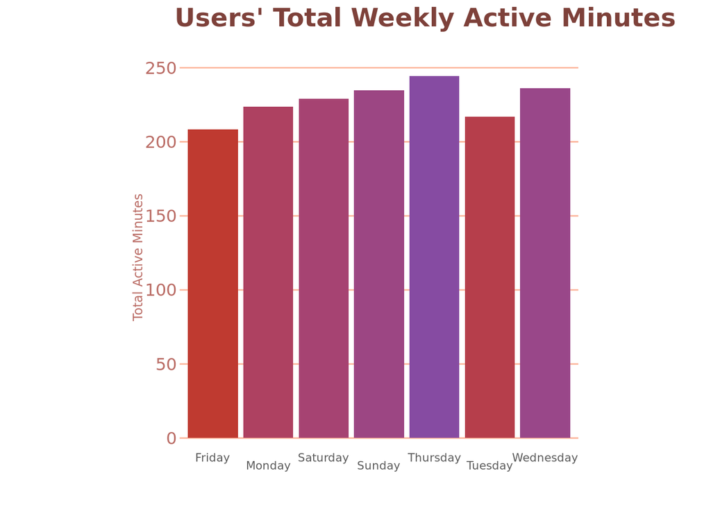

```r
ggplot(active_minutes_data, aes(x=weekday, y=total_active_minutes)) +
  geom_bar(stat="identity", aes(x=weekday, y=total_active_minutes, fill=total_active_minutes)) +
  scale_fill_gradient(low="#BF3A30", high="#864BA2", guide="none") +
  xlab("") +
  ylab("Total Active Minutes") +
  labs(title="Users' Total Weekly Active Minutes") +
  theme(aspect.ratio = 1,
        text=element_text(family="Ariel", size=15),
        plot.title=element_text(hjust=0.05, face="bold", size=18, color="#7E413A", margin=margin(b=19)),
        axis.title.x=element_text(margin=margin(t=5)),
        axis.title.y=element_text(size=9, color="#BA6C65", margin=margin(r=)),
        axis.text.x=element_text(size=8, color="#5C5C5C", margin=margin(t=-2)),
        axis.text.y.left=element_text(color="#BA6C65"),
        axis.ticks.length.x=unit(0, "cm"),
        axis.ticks.length.y=unit(0, "cm"),
        panel.grid.major.x=element_blank(),
        panel.grid.major.y=element_line(color="#FCB59C"),
        legend.title=element_text(color="#333333"),
        legend.text=element_text(color="#333333"),
        panel.background=element_rect(fill="white", color="white")) +
scale_x_discrete(guide = guide_axis(n.dodge=2))
```

Similarly, let’s find out which days were users least active:

```r
activity_analysis %>%
  group_by(weekday) %>%
  summarize(sedentary_minutes = mean(sedentary_minutes))  %>%
  arrange(desc(sedentary_minutes))
```

```
## # A tibble: 7 × 2
##   weekday   sedentary_minutes
##   <chr>                 <dbl>
## 1 Saturday              1028.
## 2 Sunday                1007.
## 3 Wednesday             1000.
## 4 Friday                 990.
## 5 Monday                 989.
## 6 Thursday               964.
## 7 Tuesday                962.
```

Users were *most active on Thursdays* and *least active on Saturdays.*

## 2. How much time do users spend in bed compared to actual minutes asleep?

National Sleep Foundation guidelines advise that healthy adults need between 7 and 9 hours of sleep per night. It’s important to wind down and get the most out of your time in bed. Next, we will compare the time spend in bed to actual minutes asleep.

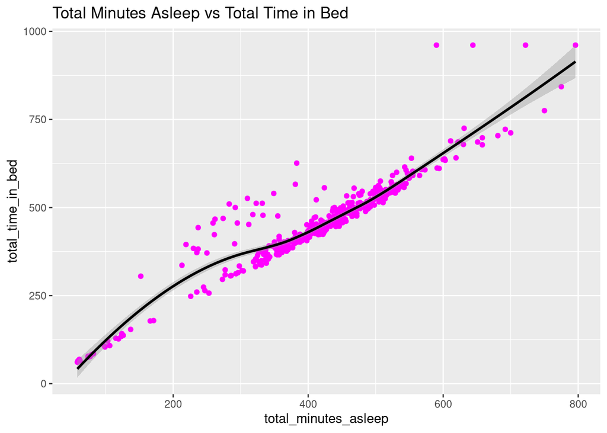

```r
ggplot(data = dailysleep) +
  geom_point(mapping = aes(x = total_minutes_asleep, y = total_time_in_bed), color =  'magenta') +
  geom_smooth(mapping = aes(x = total_minutes_asleep, y = total_time_in_bed), color = 'black') +
  labs(title = "Total Minutes Asleep vs Total Time in Bed")
```

## 3. What is the relationship between users’ calories burnt and sleep pattern?

```r
names(dailysleep)[names(dailysleep) == 'sleep_day'] <- 'date'
names(dailyActivity)[names(dailyActivity) == 'activity_date'] <- 'date'
head(dailysleep)
```

```
## # A tibble: 6 × 5
##           id date       total_sleep_records total_minutes_asleep total_time_in…¹
##        <dbl> <date>                   <dbl>                <dbl>           <dbl>
## 1 1503960366 2020-04-12                   1                  327             346
## 2 1503960366 2020-04-13                   2                  384             407
## 3 1503960366 2020-04-15                   1                  412             442
## 4 1503960366 2020-04-16                   2                  340             367
## 5 1503960366 2020-04-17                   1                  700             712
## 6 1503960366 2020-04-19                   1                  304             320
## # … with abbreviated variable name ¹total_time_in_bed
```

```r
head(dailyActivity)
```

```
## # A tibble: 6 × 15
##           id date       total_…¹ total…² track…³ logge…⁴ very_…⁵ moder…⁶ light…⁷
##        <dbl> <date>        <dbl>   <dbl>   <dbl>   <dbl>   <dbl>   <dbl>   <dbl>
## 1 1503960366 2020-04-12    13162    8.5     8.5        0    1.88   0.550    6.06
## 2 1503960366 2020-04-13    10735    6.97    6.97       0    1.57   0.690    4.71
## 3 1503960366 2020-04-14    10460    6.74    6.74       0    2.44   0.400    3.91
## 4 1503960366 2020-04-15     9762    6.28    6.28       0    2.14   1.26     2.83
## 5 1503960366 2020-04-16    12669    8.16    8.16       0    2.71   0.410    5.04
## 6 1503960366 2020-04-17     9705    6.48    6.48       0    3.19   0.780    2.51
## # … with 6 more variables: sedentary_active_distance <dbl>,
## #   very_active_minutes <dbl>, fairly_active_minutes <dbl>,
## #   lightly_active_minutes <dbl>, sedentary_minutes <dbl>, calories <dbl>, and
## #   abbreviated variable names ¹total_steps, ²total_distance,
## #   ³tracker_distance, ⁴logged_activities_distance, ⁵very_active_distance,
## #   ⁶moderately_active_distance, ⁷light_active_distance
```

We will perform a full INNER JOIN to combine sleep data and activitie data. By doing this, we ensure that only the most relavent data entries are considered.

```r
dailycal_dailysleep<- merge(dailyActivity, dailysleep, by=c ('id', 'date'), all = FALSE)
head(dailycal_dailysleep)
```

```
##           id       date total_steps total_distance tracker_distance
## 1 1503960366 2020-04-12       13162           8.50             8.50
## 2 1503960366 2020-04-13       10735           6.97             6.97
## 3 1503960366 2020-04-15        9762           6.28             6.28
## 4 1503960366 2020-04-16       12669           8.16             8.16
## 5 1503960366 2020-04-17        9705           6.48             6.48
## 6 1503960366 2020-04-19       15506           9.88             9.88
##   logged_activities_distance very_active_distance moderately_active_distance
## 1                          0                 1.88                       0.55
## 2                          0                 1.57                       0.69
## 3                          0                 2.14                       1.26
## 4                          0                 2.71                       0.41
## 5                          0                 3.19                       0.78
## 6                          0                 3.53                       1.32
##   light_active_distance sedentary_active_distance very_active_minutes
```

[output cut: 20 more lines]

We can also create a new data frame from the existing one with just the sleep and calories columns.

```r
dailycal_dailysleep_merged<- dailycal_dailysleep[, c("id", "date", "calories","total_minutes_asleep")]
head(dailycal_dailysleep_merged)
```

```
##           id       date calories total_minutes_asleep
## 1 1503960366 2020-04-12     1985                  327
## 2 1503960366 2020-04-13     1797                  384
## 3 1503960366 2020-04-15     1745                  412
## 4 1503960366 2020-04-16     1863                  340
## 5 1503960366 2020-04-17     1728                  700
## 6 1503960366 2020-04-19     2035                  304
```

```r
cor.test(dailycal_dailysleep_merged$total_minutes_asleep, dailycal_dailysleep_merged$total_minutes_asleep, method=c("pearson"))
```

```
##
##  Pearson's product-moment correlation
##
## data:  dailycal_dailysleep_merged$total_minutes_asleep and dailycal_dailysleep_merged$total_minutes_asleep
## t = Inf, df = 408, p-value < 2.2e-16
## alternative hypothesis: true correlation is not equal to 0
## 95 percent confidence interval:
##  1 1
## sample estimates:
## cor
##   1
```

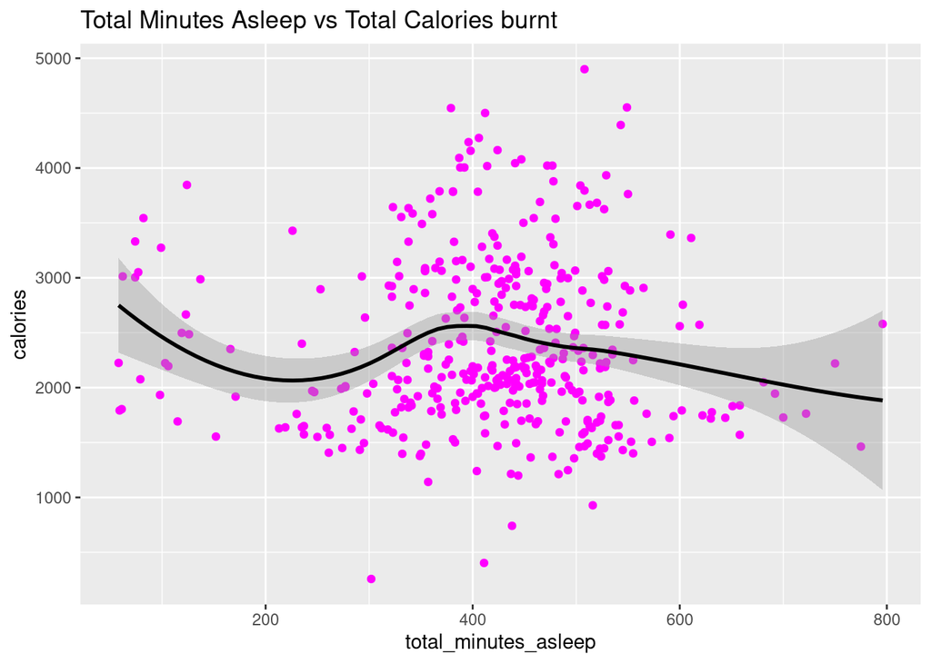

```r
ggplot(data = dailycal_dailysleep_merged) +
  geom_point(mapping = aes(x = total_minutes_asleep, y = calories), color =  'magenta') +
  geom_smooth(mapping = aes(x = total_minutes_asleep, y = calories), color = 'black') +
  labs(title = "Total Minutes Asleep vs Total Calories burnt")
```

# Analysis - Summary

# Recommendations:

First, we should acknowledge that the data set used for this case study is small. Nevertheless, we gained significant insights from this study. Following are the recommendations for Bellabeat:

### 1. Notifications:

Sometimes a nudge in the right direction is all we need to stay on track of our fitness goals. We saw from user data that users tend to be lethargic on Saturdays. The Bellabeat fitness app can send out push notifications to motivate users by reminding them of how well they did on weekdays. Constant reminders like this will ensure user traffic